# Budweiser Executive Analysis

The following markdown file contains an in depth analysis on the Brewery and Beers data set. The data set focuses on craft beers and breweries in the United states. The document starts at a high level data exploratory faces and delves deeper into analyis and concludes with a suggested route to market based on the analyis.

Package setup:

```r
library(tidyr)
library(dplyr)
library(XML) #xml_Parse
library(dplyr)
library(tidyr)
library(stringi)
library(rvest) #html_table, html_node
```

```r
library(ggplot2)
library(RCurl) #getURL
library(rmarkdown)
library(class)
library(caret)
library(e1071)
library(data.table)
summary(cars)
```

```
##      speed           dist
##  Min.   : 4.0   Min.   :  2.00
##  1st Qu.:12.0   1st Qu.: 26.00
##  Median :15.0   Median : 36.00
##  Mean   :15.4   Mean   : 42.98
##  3rd Qu.:19.0   3rd Qu.: 56.00
##  Max.   :25.0   Max.   :120.00
```

```r
beers = read.csv("/Users/Izzino/Documents/MDS-6306-Doing-Data-Science-Fall-2019/Unit 8 and 9 Case Study 1/Beers.csv")  # read csv file
breweries = read.csv("/Users/Izzino/Documents/MDS-6306-Doing-Data-Science-Fall-2019/Unit 8 and 9 Case Study 1/Breweries.csv")  # read csv file
```

The command below contains the funciton used to address the NA in the data mentioned in question 3.

```r
completeFun <- function(data, desiredCols) {
  completeVec <- complete.cases(data[, desiredCols])
  return(data[completeVec, ])
}
```

Brewery Count by State:

```r
countbystate <- breweries %>% group_by(State) %>%summarise(no_rows = length(State))
print((countbystate), n = 100)
```

```
## # A tibble: 51 x 2
##    State no_rows
##    <fct>   <int>
##  1 " AK"       7
##  2 " AL"       3
##  3 " AR"       2
##  4 " AZ"      11
##  5 " CA"      39
##  6 " CO"      47
##  7 " CT"       8
##  8 " DC"       1
##  9 " DE"       2
## 10 " FL"      15
## 11 " GA"       7
## 12 " HI"       4
```

[output cut: 39 more lines]

*Merging the Breweries and Beers Dataset:

```r
bb <- merge.data.frame(beers, breweries, by.x = "Brewery_id", by.y = "Brew_ID")
```

*First and Last 6 data points in merged set

```r
head(bb,n=6)
```

```
##   Brewery_id        Name.x Beer_ID   ABV IBU
## 1          1  Get Together    2692 0.045  50
## 2          1 Maggie's Leap    2691 0.049  26
## 3          1    Wall's End    2690 0.048  19
## 4          1       Pumpion    2689 0.060  38
## 5          1    Stronghold    2688 0.060  25
## 6          1   Parapet ESB    2687 0.056  47
##                                 Style Ounces             Name.y
## 1                        American IPA     16 NorthGate Brewing
## 2                  Milk / Sweet Stout     16 NorthGate Brewing
## 3                   English Brown Ale     16 NorthGate Brewing
## 4                         Pumpkin Ale     16 NorthGate Brewing
## 5                     American Porter     16 NorthGate Brewing
## 6 Extra Special / Strong Bitter (ESB)     16 NorthGate Brewing
##          City State
## 1 Minneapolis    MN
## 2 Minneapolis    MN
## 3 Minneapolis    MN
## 4 Minneapolis    MN
## 5 Minneapolis    MN
## 6 Minneapolis    MN
```

```r
tail(bb,n=6)
```

```
##      Brewery_id                    Name.x Beer_ID   ABV IBU
## 2405        556             Pilsner Ukiah      98 0.055  NA
## 2406        557  Heinnieweisse Weissebier      52 0.049  NA
## 2407        557           Snapperhead IPA      51 0.068  NA
## 2408        557         Moo Thunder Stout      50 0.049  NA
## 2409        557         Porkslap Pale Ale      49 0.043  NA
## 2410        558 Urban Wilderness Pale Ale      30 0.049  NA
##                        Style Ounces                        Name.y
## 2405         German Pilsener     12         Ukiah Brewing Company
## 2406              Hefeweizen     12       Butternuts Beer and Ale
## 2407            American IPA     12       Butternuts Beer and Ale
## 2408      Milk / Sweet Stout     12       Butternuts Beer and Ale
## 2409 American Pale Ale (APA)     12       Butternuts Beer and Ale
## 2410        English Pale Ale     12 Sleeping Lady Brewing Company
##               City State
## 2405         Ukiah    CA
## 2406 Garrattsville    NY
## 2407 Garrattsville    NY
## 2408 Garrattsville    NY
## 2409 Garrattsville    NY
## 2410     Anchorage    AK
```

```r
bb[1:6,]
```

```
##   Brewery_id        Name.x Beer_ID   ABV IBU
## 1          1  Get Together    2692 0.045  50
## 2          1 Maggie's Leap    2691 0.049  26
## 3          1    Wall's End    2690 0.048  19
## 4          1       Pumpion    2689 0.060  38
## 5          1    Stronghold    2688 0.060  25
## 6          1   Parapet ESB    2687 0.056  47
##                                 Style Ounces             Name.y
## 1                        American IPA     16 NorthGate Brewing
## 2                  Milk / Sweet Stout     16 NorthGate Brewing
## 3                   English Brown Ale     16 NorthGate Brewing
## 4                         Pumpkin Ale     16 NorthGate Brewing
## 5                     American Porter     16 NorthGate Brewing
## 6 Extra Special / Strong Bitter (ESB)     16 NorthGate Brewing
##          City State
## 1 Minneapolis    MN
## 2 Minneapolis    MN
## 3 Minneapolis    MN
## 4 Minneapolis    MN
## 5 Minneapolis    MN
## 6 Minneapolis    MN
```

*Using the complete funtion create above I can cleanse the IBU column of nulls. During my eda process I found that the only abv nulls are directly corelated to ibu nulls. This command results in a clean data set:

```r
bbibu <- completeFun(bb, "IBU")
bbabv <- completeFun(bb, "ABV")
bba <- completeFun(bbabv,"IBU")
install.packages('/Users/Izzino/Downloads/doBy_4.6-2.tar.gz', repos = NULL, type="source")
library(doBy)
```

*The code below results in mean, max, min, median, sd by state for IBU and ABV and merges the two stat dataframes into one:

```r
bbmibu <- summaryBy(IBU ~ State, data = bba,
          FUN = list(mean, max, min, median, sd))
bbmabv <- summaryBy(ABV ~ State, data = bba,
          FUN = list(mean, max, min, median, sd))
bbstat <- merge(bbmabv,bbmibu,by="State")
```

ABV and IBU values by State:

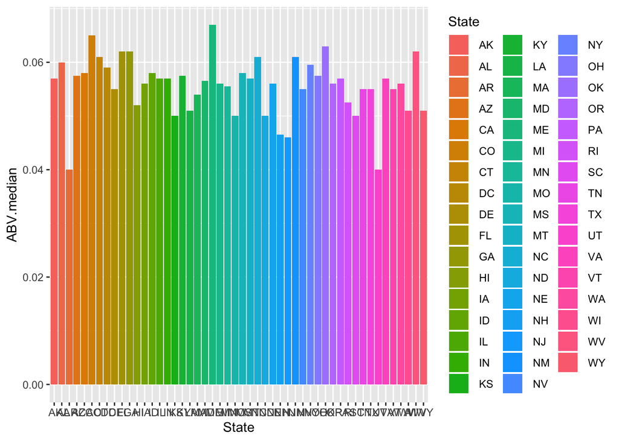

```r
ggplot(bbstat,aes(y = ABV.median, x  = State, fill = State))+geom_bar(stat = "identity")
```

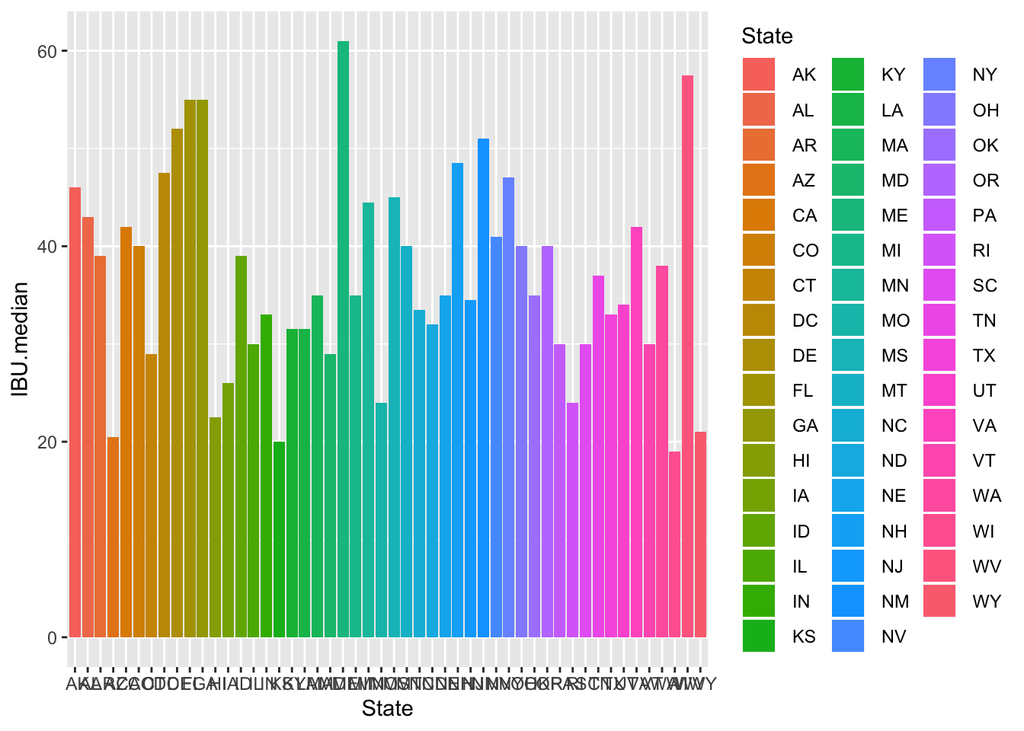

```r
ggplot(bbstat,aes(y = IBU.median, x  = State, fill = State))+geom_bar(stat = "identity")
```

Brewery and Beer information on beers with the highest ABV and IBU. You can see that Kentucky has the highest ABV while Oregon leads in max IBU.

```r
bbibu[which.max(bbibu$ABV),]
```

```
##   Brewery_id         Name.x Beer_ID   ABV IBU              Style Ounces
## 8          2 London Balling    2685 0.125  80 English Barleywine     16
##                      Name.y       City State
## 8 Against the Grain Brewery Louisville    KY
```

```r
bbibu[which.max(bbibu$IBU),]
```

```
##      Brewery_id                    Name.x Beer_ID   ABV IBU
## 1857        375 Bitter Bitch Imperial IPA     980 0.082 138
##                               Style Ounces                  Name.y    City
## 1857 American Double / Imperial IPA     12 Astoria Brewing Company Astoria
##      State
## 1857    OR
```

Looking at the hisogram below it is clear to see the the range of 4%-6% abv is the most popular range for beer in the united states. The highest and lowest of the charts ar shown to be outliers:

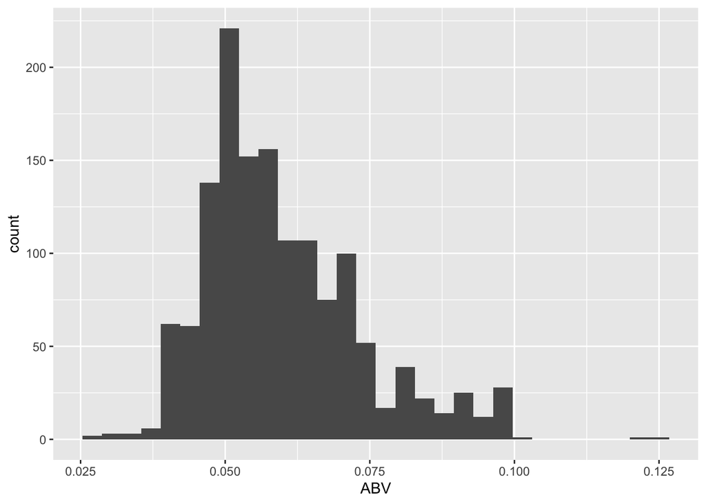

```r
ggplot(bbibu, aes(x= ABV, fill = ABV , color = ABV)) + geom_histogram()
```

Below you can see a scatter plot showing ABV and IBU correlation. By looking at the general upward movement of the trend line it can be assumed that there is a positive correlation between IBU and ABV, which is expected since alcohol has a bittering effect.

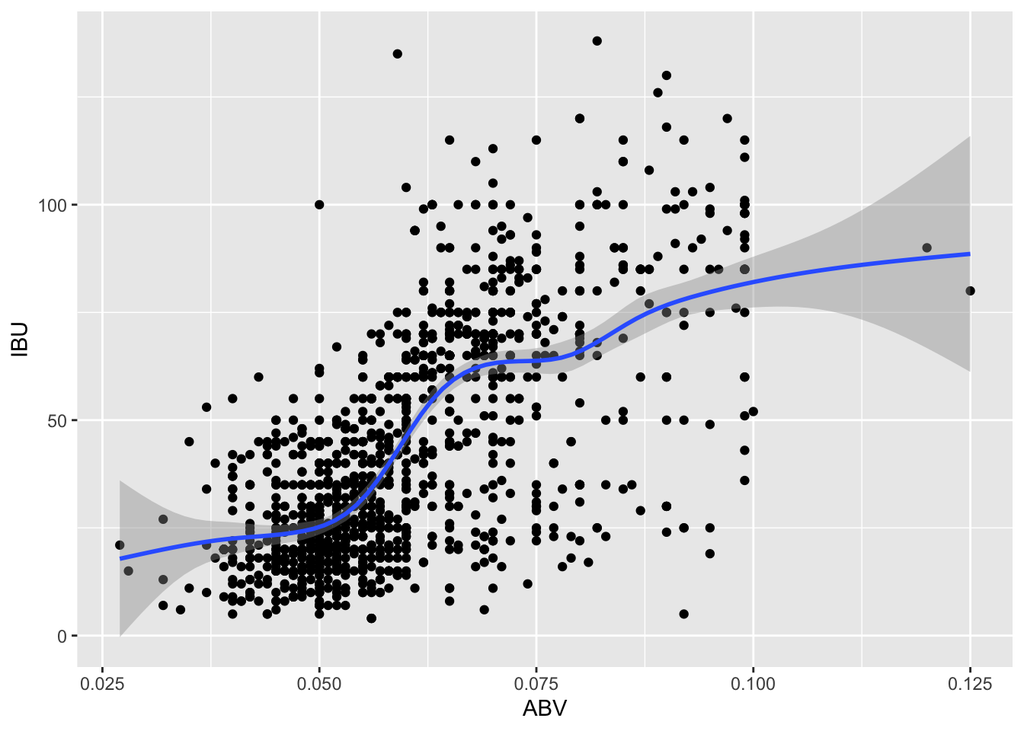

```r
ggplot(data = bba, mapping = aes(x = ABV, y = IBU)) +
  geom_point()+
  geom_smooth()
```

One of the more complex questions asked out of the analysis was to investigate the difference with respect to IBU and ABV between IPAs (India Pale Ales) and other types of Ale. Using KNN which a statistical model used to classify like items together I created model that tested ABV and IBU as predictors to whether or not a beer was and IPA or a regular Ale.

```r
bbibu$IPA <- ifelse(grepl("IPA", bbibu$Style), "yes", "no")
bbibu$Ale <- ifelse(grepl("Ale", bbibu$Style), "yes", "no")


bbibu1 <-subset(bbibu, (IPA =='yes')  || (Ale =='yes'))



trainIndices = sample(1:dim(bbibu1)[1],round(.20 * dim(bbibu1)[1]))
train = bbibu1[trainIndices,]
test = bbibu1[-trainIndices,]

classifications = knn(train[,c("ABV","IBU")],test[,c("ABV","IBU")],train$IPA, prob = TRUE, k = 6)
table = table(classifications,test$IPA)
confusionMatrix(table)
```

```
## Confusion Matrix and Statistics
##
##
## classifications  no yes
##             no  745  96
##             yes  63 220
##
##                Accuracy : 0.8585
##                  95% CI : (0.8368, 0.8784)
##     No Information Rate : 0.7189
##     P-Value [Acc > NIR] : < 2e-16
##
##                   Kappa : 0.6385
##
##  Mcnemar's Test P-Value : 0.01116
##
##             Sensitivity : 0.9220
##             Specificity : 0.6962
##          Pos Pred Value : 0.8859
##          Neg Pred Value : 0.7774
##              Prevalence : 0.7189
##          Detection Rate : 0.6628
##    Detection Prevalence : 0.7482
##       Balanced Accuracy : 0.8091
##
##        'Positive' Class : no
##
```

Here is a visualization of the correlation between IBU ABV and how it relates to IPA vs ALE:

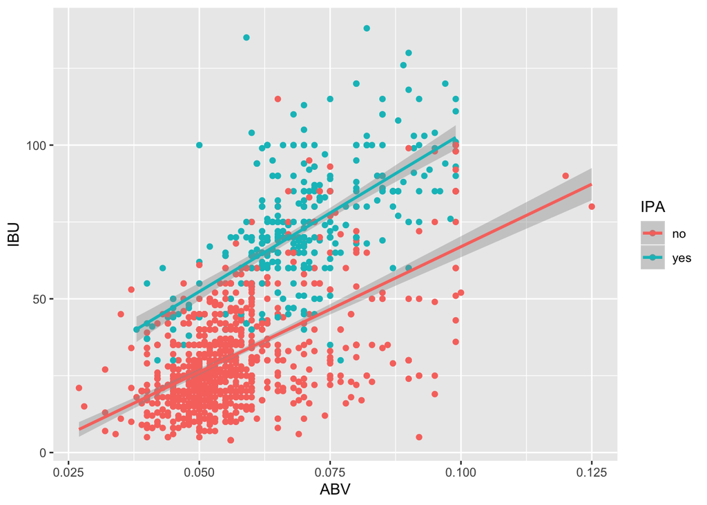

```r
ggplot(data = bbibu1, mapping = aes(x = ABV, y = IBU,color = IPA)) +
  geom_point()+
  geom_smooth(method = lm)
```

Since the executive staff showed interest in the relationship IBU and ABV as it pertained to determining whether a beer was an IPA or an Ale I extended the analysis to view ABV distibution for IPAs and they’re Styles to determine potential areas of market entry into the IPA space.

Looking at the historgram below in comparison to the histogram of abv for all beers its easy to see that is more common for IPAs to have a higher ABV:

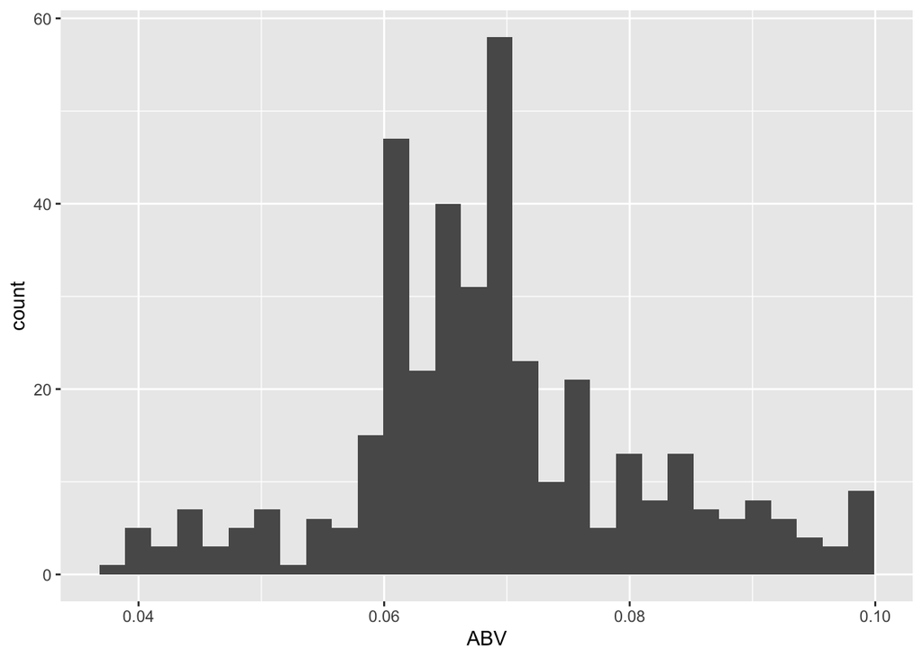

```r
bbuIPA <- subset(bbibu, (IPA =='yes'))

ggplot(bbuIPA, aes(x= ABV)) + geom_histogram()
```

Another interesting finding with IPAs there is a stronger correlation between bitterness and alcohol content seen in the scatter plot below:

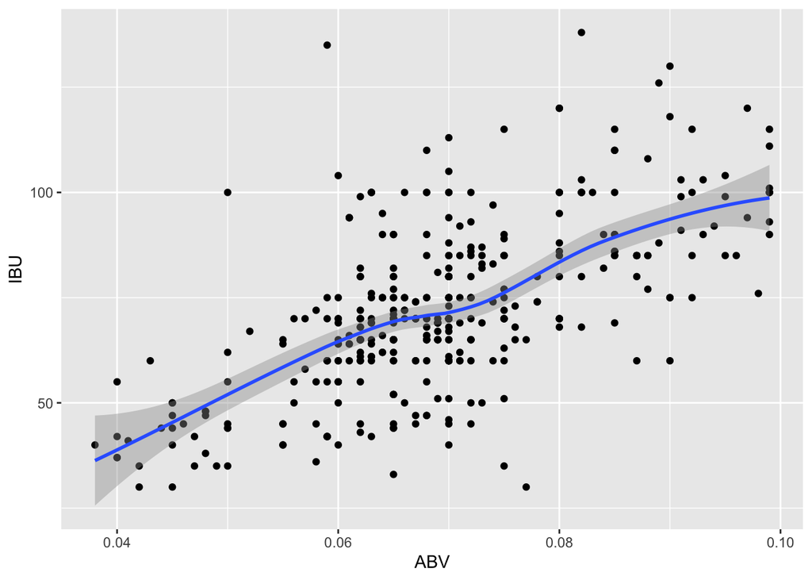

```r
ggplot(data = bbuIPA, mapping = aes(x = ABV, y = IBU)) +
  geom_point()+
  geom_smooth()
```

Finally looking at the histogram from earlier with an overlay containting beer style it is easy to see the the “Imperial IPA” dominates the high alcohol content IPA space:

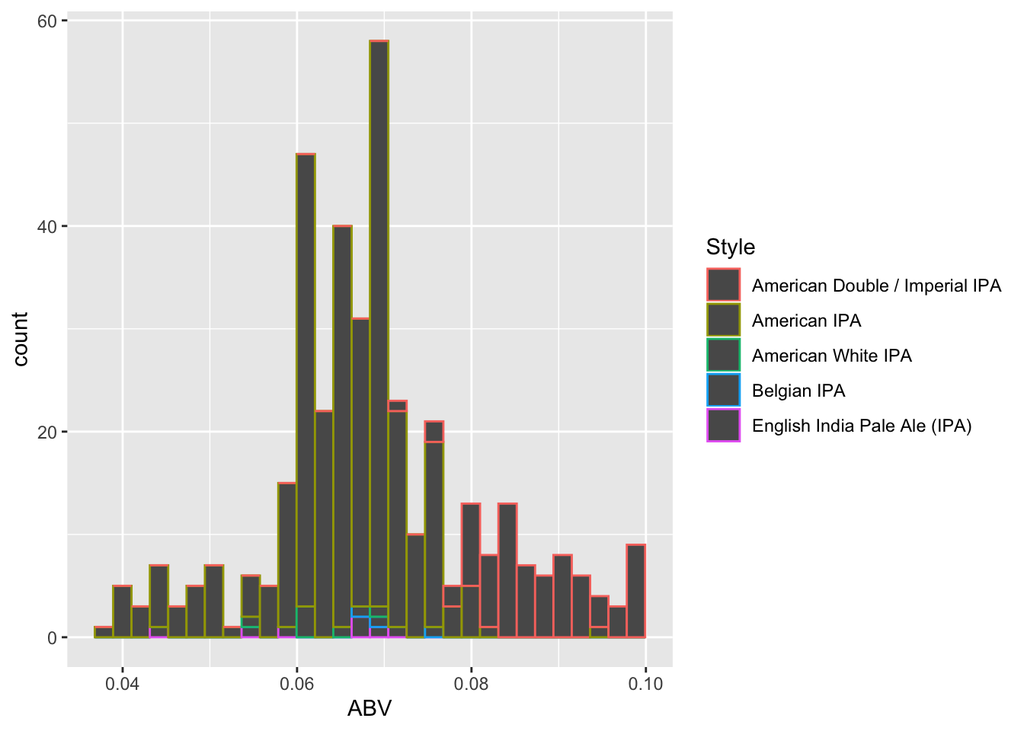

```r
bbuIPA <- subset(bbibu, (IPA =='yes'))

ggplot(bbuIPA, aes(x= ABV, fill = IBU , color = Style)) + geom_histogram()
```

With a bit of research into the IRI: US Beer Sales data set it was shown that the more popular IPAs did not have the level of bitterness or percieved hopppiness of the average Imperial IPA. With this information I believe that there is a strong case into looking int creating a high abv IPA with a lower IBU to compete in a untapped market space.